# Latihan Praktikum

2025-08-29

##Persiapan Library

```r
library("forecast")
```

```r
library("graphics")
library("TTR")
library("TSA")
```

##Data

```r
a = read.csv("D:/csv kuliah/coffee_prices.csv")
```

##Preprocessing Data

```r
library(dplyr)
b <- a %>%
  slice(400:500)

View(b)
str(b)
```

```
## 'data.frame':    101 obs. of  3 variables:
##  $ X                     : int  400 401 402 403 404 405 406 407 408 409 ...
##  $ Date..Monthly.        : chr  "4/1/1993" "5/1/1993" "6/1/1993" "7/1/1993" ...
##  $ Coffee.Arabica.....kg.: num  1.28 1.37 1.38 1.58 1.7 ...
```

```r
dim(b)
```

```
## [1] 101   3
```

```r
b$Date..Monthly. <- format(as.Date(b$Date..Monthly., format = "%m/%d/%Y"), "%m/%Y")

head(b)
```

```
##     X Date..Monthly. Coffee.Arabica.....kg.
## 1 400        04/1993                 1.2758
## 2 401        05/1993                 1.3708
## 3 402        06/1993                 1.3779
## 4 403        07/1993                 1.5831
## 5 404        08/1993                 1.6958
## 6 405        09/1993                 1.7807
```

```r
b.ts <- ts(b$Coffee.Arabica.....kg.)
summary(b.ts)
```

```
##    Min. 1st Qu.  Median    Mean 3rd Qu.    Max.
##   1.276   1.906   2.588   2.713   3.406   5.892
```

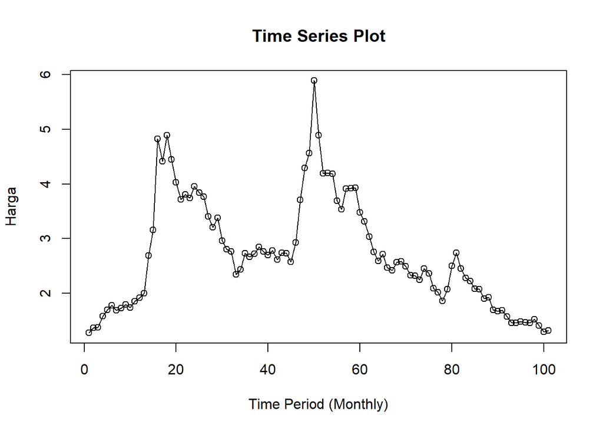

```r
ts.plot(b.ts, xlab="Time Period (Monthly)", ylab="Harga",
        main = "Time Series Plot")
points(b.ts)
```

##Pembagian Data

```r
# hitung jumlah data
n <- nrow(b)
#80 20 buat data konstan biasanya
# tentukan batas 80%
n_train <- floor(0.8 * n)

# bagi data
train_ma <- b[1:n_train, ]
test_ma  <- b[(n_train+1):n, ]

# ubah ke time series
train_ma.ts <- ts(train_ma$Coffee.Arabica.....kg.)
test_ma.ts  <- ts(test_ma$Coffee.Arabica.....kg.)
data.sma<-SMA(train_ma.ts, n=4)
data.sma
```

```
## Time Series:
## Start = 1
## End = 80
## Frequency = 1
##  [1]       NA       NA       NA 1.401900 1.506900 1.609375 1.687300 1.724725
##  [9] 1.748800 1.738750 1.778925 1.825250 1.876400 2.113025 2.440975 3.167850
## [17] 3.773400 4.325225 4.647200 4.448925 4.273125 4.000950 3.824225 3.805050
## [25] 3.837350 3.828475 3.744175 3.558025 3.441225 3.239775 3.089750 2.977275
## [33] 2.718400 2.587175 2.569650 2.545350 2.640475 2.743100 2.750650 2.759625
## [41] 2.774625 2.716375 2.709425 2.718250 2.667525 2.745575 2.989025 3.378300
## [49] 3.874175 4.614975 4.910675 4.887025 4.797800 4.371200 4.071600 3.905475
## [57] 3.831850 3.765325 3.823300 3.808875 3.659550 3.438650 3.145150 2.924400
## [65] 2.774825 2.632250 2.548425 2.541650 2.509575 2.515675 2.492300 2.431775
## [73] 2.347550 2.337150 2.346700 2.288625 2.229450 2.081950 2.010250 2.112375
```

##Eksplorasi Data

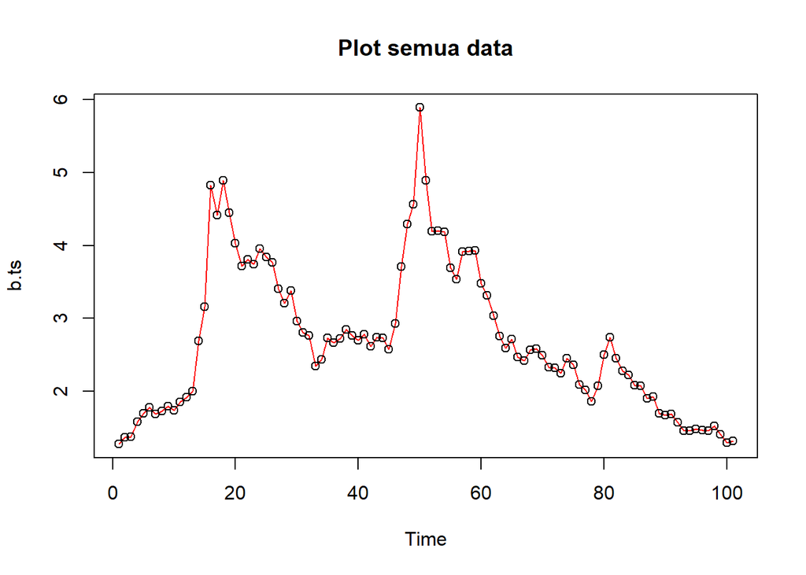

```r
#eksplorasi keseluruhan data
plot(b.ts, col="red",main="Plot semua data")
points(b.ts)
```

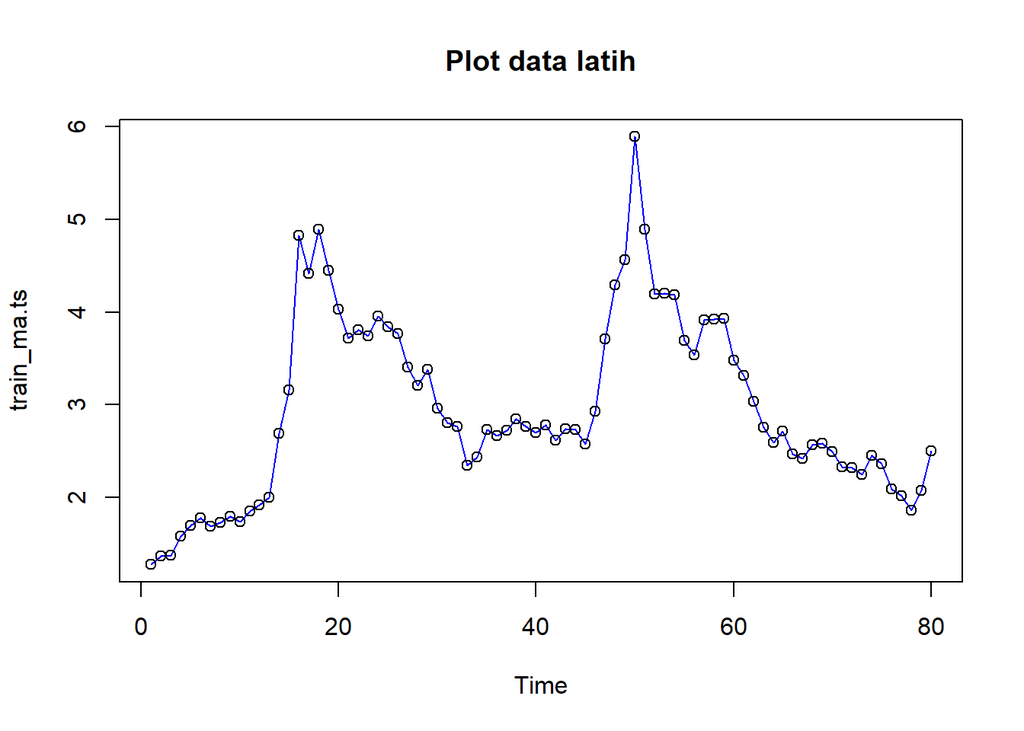

```r
#eksplorasi data latih
plot(train_ma.ts, col="blue",main="Plot data latih")
points(train_ma.ts)
```

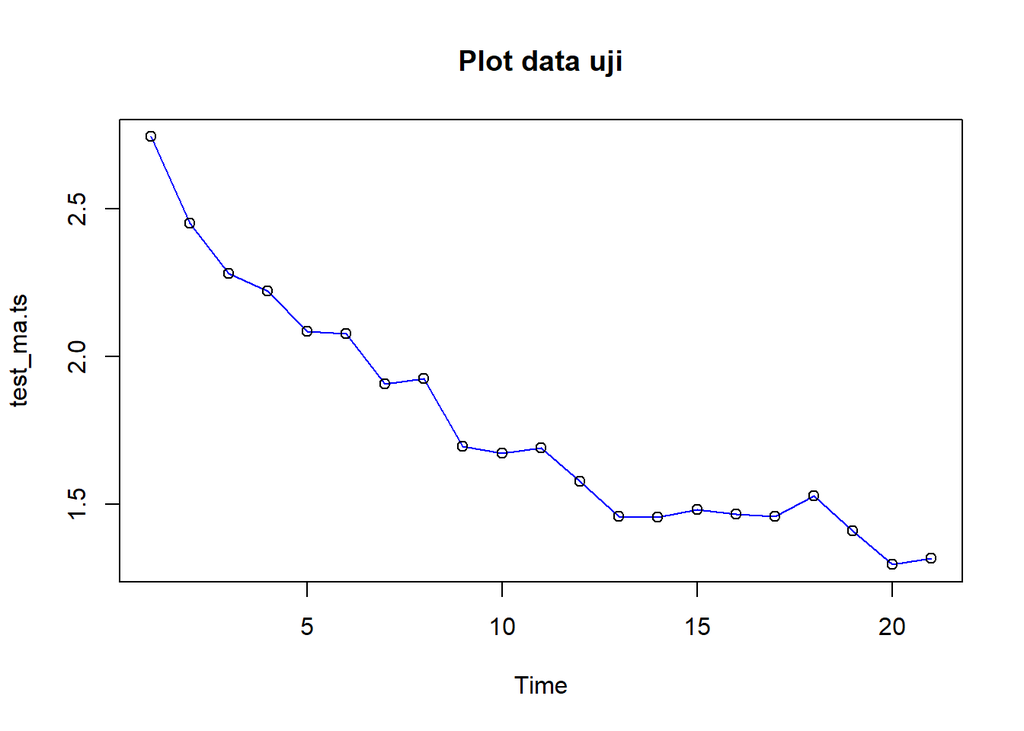

```r
#eksplorasi data uji
plot(test_ma.ts, col="blue",main="Plot data uji")
points(test_ma.ts)
```

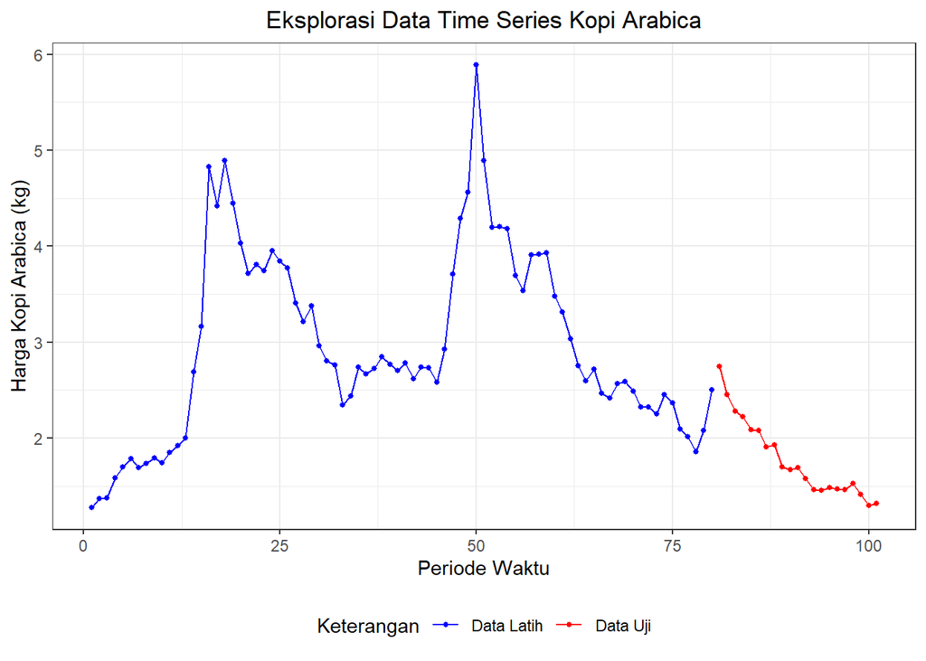

```r
library(ggplot2)

# Tambahkan kolom period (index waktu)
b$Period <- 1:nrow(b)

# Tambah label jenis data (latih / uji)
b$JenisData <- ifelse(b$Period <= n_train, "Data Latih", "Data Uji")

# Plot keseluruhan, latih, dan uji dalam satu grafik
ggplot(b, aes(x = Period, y = Coffee.Arabica.....kg.)) +
  geom_line(aes(color = JenisData)) +
  geom_point(aes(color = JenisData), size = 1) +
  labs(title = "Eksplorasi Data Time Series Kopi Arabica",
       x = "Periode Waktu",
       y = "Harga Kopi Arabica (kg)",
       color = "Keterangan") +
  scale_color_manual(values = c("Data Latih" = "blue", "Data Uji" = "red")) +
  theme_bw() +
  theme(legend.position = "bottom",
        plot.title = element_text(hjust = 0.5))
```

Karena pola data cenderung seperti data trend maka akan digunakan Double Moving Average (DMA)

##Double Moving Average (DMA)

```r
library(TTR)

# data asli
data.sma <- SMA(b.ts, n = 4)   # SMA pertama
dma <- SMA(data.sma, n = 4)        # SMA kedua

# At dan Bt (hati2: hanya valid setelah data.sma & dma tidak NA)
At <- 2 * data.sma - dma
Bt <- (2 / (4 - 1)) * (data.sma - dma)

# ramalan in-sample (sampai panjang data asli)
data.dma <- At + Bt

# horizon ramalan (misal 24 periode ke depan)
h <- 24
t <- 1:h
f <- numeric(h)    # vektor kosong utk ramalan

# ramalan out-of-sample (menggunakan At & Bt terakhir yg bukan NA)
last.At <- tail(At[!is.na(At)], 1)
last.Bt <- tail(Bt[!is.na(Bt)], 1)
for (i in 1:h) {
  f[i] <- last.At + last.Bt * i
}

# gabungkan semua ke data.frame dengan panjang yg sama
dt22 <- data.frame(
  aktual     = c(b.ts, rep(NA, h)),
  pemulusan1 = c(data.sma, rep(NA, h)),
  pemulusan2 = c(dma, rep(NA, h)),
  At         = c(At, rep(NA, h)),
  Bt         = c(Bt, rep(NA, h)),
  ramalan    = c(data.dma, f)   # in-sample + out-of-sample
)
dt22
```

```
##     aktual pemulusan1 pemulusan2       At           Bt   ramalan
## 1   1.2758         NA         NA       NA           NA        NA
## 2   1.3708         NA         NA       NA           NA        NA
## 3   1.3779         NA         NA       NA           NA        NA
## 4   1.5831   1.401900         NA       NA           NA        NA
## 5   1.6958   1.506900         NA       NA           NA        NA
## 6   1.7807   1.609375         NA       NA           NA        NA
## 7   1.6896   1.687300   1.551369 1.823231  0.090620833 1.9138521
## 8   1.7328   1.724725   1.632075 1.817375  0.061766667 1.8791417
## 9   1.7921   1.748800   1.692550 1.805050  0.037500000 1.8425500
## 10  1.7405   1.738750   1.724894 1.752606  0.009237500 1.7618438
## 11  1.8503   1.778925   1.747800 1.810050  0.020750000 1.8308000
## 12  1.9181   1.825250   1.772931 1.877569  0.034879167 1.9124479
## 13  1.9967   1.876400   1.804831 1.947969  0.047712500 1.9956813
## 14  2.6870   2.113025   1.898400 2.327650  0.143083333 2.4707333
```

[output cut: 111 more lines]

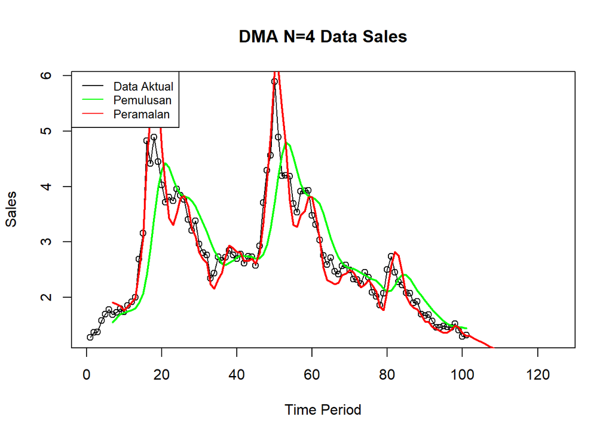

```r
ts.plot(dt22$aktual,
        xlab="Time Period",
        ylab="Sales",
        main="DMA N=4 Data Sales")

points(dt22$aktual)

# pemulusan (kolom ke-3 = pemulusan2)
lines(dt22$pemulusan2, col="green", lwd=2)

# ramalan (kolom ke-6)
lines(dt22$ramalan, col="red", lwd=2)

legend("topleft",
       legend=c("Data Aktual","Pemulusan","Peramalan"),
       lty=1, col=c("black","green","red"), cex=0.8)
```

##Hitung Akurasi Data Latih

```r
#Menghitung nilai keakuratan data latih
error_train.dma = train_ma.ts-dt22$ramalan[1:length(train_ma.ts)]

SSE_train.dma = sum(error_train.dma[8:length(train_ma.ts)]^2)
MSE_train.dma = mean(error_train.dma[8:length(train_ma.ts)]^2)
MAPE_train.dma = mean(abs((error_train.dma[8:length(train_ma.ts)]/train_ma.ts[8:length(train_ma.ts)])*100))

akurasi_train.dma <- matrix(c(SSE_train.dma, MSE_train.dma, MAPE_train.dma))
row.names(akurasi_train.dma)<- c("SSE", "MSE", "MAPE")
colnames(akurasi_train.dma) <- c("Akurasi m = 4")
akurasi_train.dma
```

```
##      Akurasi m = 4
## SSE     10.4610575
## MSE      0.1433022
## MAPE     7.4184113
```

Model sudah fit dengan baik terhadap data latih. Kesalahan rata-rata relatif terhadap nilai aktual hanya ~7% dari MAPE, sehingga bisa diandalkan. SSE dan MSE yang relatif kecil memperkuat bukti bahwa model tidak terlalu banyak error.

##Hitung Akurasi Data Uji

```r
error_test.dma = test_ma.ts-dt22[100:120,6]
SSE_test.dma = sum(error_test.dma^2)
MSE_test.dma = mean(error_test.dma^2)
MAPE_test.dma = mean(abs((error_test.dma/test_ma.ts*100)))

akurasi_test.dma <- matrix(c(SSE_test.dma, MSE_test.dma, MAPE_test.dma))
row.names(akurasi_test.dma)<- c("SSE", "MSE", "MAPE")
colnames(akurasi_test.dma) <- c("Akurasi m = 4")
akurasi_test.dma
```

```
##      Akurasi m = 4
## SSE     12.8763156
## MSE      0.6131579
## MAPE    42.3266135
```

##Pembagian Data Untuk DES

```r
# hitung jumlah data
n <- nrow(b)
n_train <- floor(0.8 * n)

# bagi data
train_des <- b[1:n_train, ]
test_des  <- b[(n_train+1):n, ]

# ubah ke time series
trai.ts <- ts(train_des$Coffee.Arabica.....kg.)
tes.ts  <- ts(test_des$Coffee.Arabica.....kg.)
```

##Double Exponential Smoothing (DES)

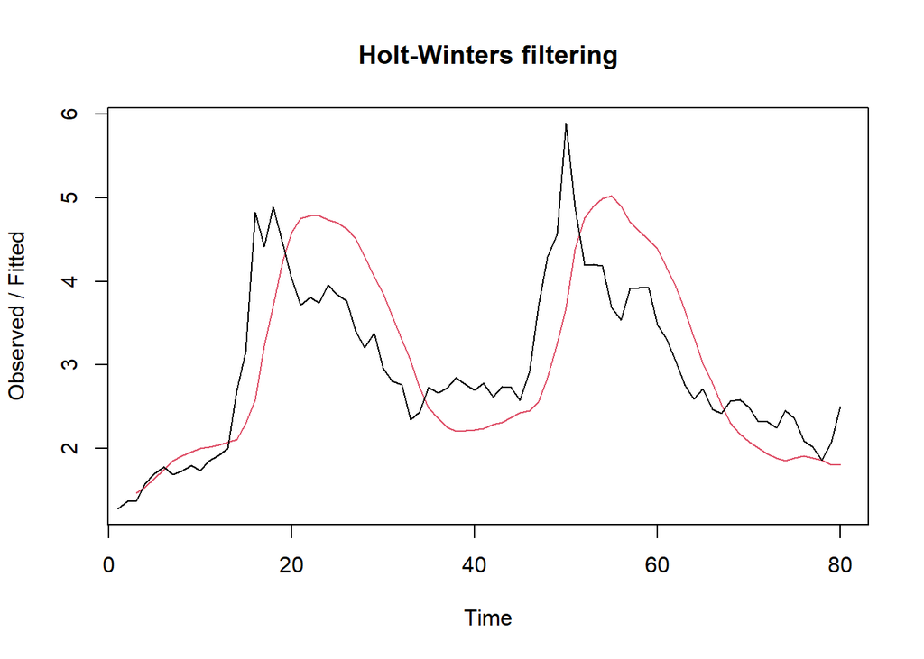

```r
#Lamda=0.2 dan gamma=0.2
des.1<- HoltWinters(trai.ts, gamma = FALSE, beta = 0.2, alpha = 0.2)
plot(des.1)
```

```r
#ramalan
ramalandes1<- forecast(des.1, h=21)
ramalandes1
```

```
##     Point Forecast       Lo 80    Hi 80        Lo 95    Hi 95
##  81       1.933660  0.95622900 2.911092  0.438808065 3.428513
##  82       1.917008  0.91182052 2.922195  0.379706477 3.454309
##  83       1.900355  0.85857666 2.942134  0.307092341 3.493618
##  84       1.883703  0.79598365 2.971422  0.220179921 3.547226
##  85       1.867050  0.72383147 3.010269  0.118648008 3.615452
##  86       1.850398  0.64217225 3.058623  0.002576343 3.698219
##  87       1.833745  0.55125975 3.116231 -0.127646995 3.795137
##  88       1.817093  0.45148411 3.182701 -0.271425343 3.905611
##  89       1.800440  0.34331302 3.257567 -0.428043424 4.028923
##  90       1.783787  0.22724521 3.340330 -0.596738492 4.164313
##  91       1.767135  0.10377754 3.430492 -0.776750677 4.311021
##  92       1.750482 -0.02661588 3.527581 -0.967354885 4.468320
##  93       1.733830 -0.16349522 3.631155 -1.167878431 4.635538
##  94       1.717177 -0.30645986 3.740814 -1.377708653 4.812063
##  95       1.700525 -0.45514923 3.856199 -1.596294099 4.997344
##  96       1.683872 -0.60924107 3.976985 -1.823141915 5.190886
##  97       1.667220 -0.76844845 4.102888 -2.057813257 5.392253
##  98       1.650567 -0.93251619 4.233650 -2.299917891 5.601052
##  99       1.633915 -1.10121731 4.369046 -2.549108662 5.816938
## 100       1.617262 -1.27434954 4.508874 -2.805076227 6.039600
## 101       1.600609 -1.45173219 4.652951 -3.067544248 6.268763
```

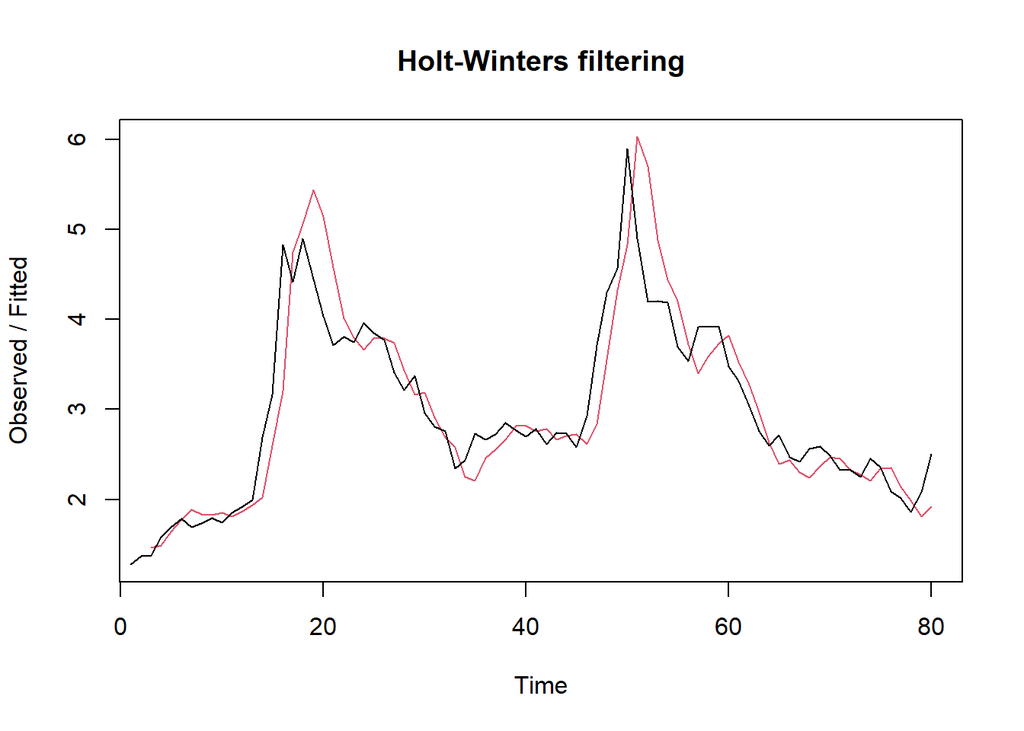

```r
#Lamda=0.6 dan gamma=0.3
des.2<- HoltWinters(trai.ts, gamma = FALSE, beta = 0.3, alpha = 0.6)
plot(des.2)
```

```r
#ramalan
ramalandes2<- forecast(des.2, h=21)
ramalandes2
```

```
##     Point Forecast       Lo 80     Hi 80       Lo 95     Hi 95
##  81       2.320427  1.73632402  2.904530  1.42711849  3.213736
##  82       2.373397  1.63262155  3.114172  1.24047872  3.506315
##  83       2.426367  1.49729390  3.355440  1.00547240  3.847261
##  84       2.479337  1.33628397  3.622389  0.73118842  4.227485
##  85       2.532306  1.15352610  3.911087  0.42364386  4.640969
##  86       2.585276  0.95166607  4.218887  0.08688505  5.083668
##  87       2.638246  0.73256545  4.543927 -0.27624097  5.552733
##  88       2.691216  0.49759954  4.884832 -0.66363085  6.046063
##  89       2.744186  0.24782985  5.240542 -1.07366118  6.562033
##  90       2.797156 -0.01589382  5.610205 -1.50503225  7.099344
##  91       2.850125 -0.29287052  5.993121 -1.95667209  7.656923
##  92       2.903095 -0.58250807  6.388699 -2.42767505  8.233866
##  93       2.956065 -0.88429642  6.796427 -2.91726102  8.829391
##  94       3.009035 -1.19778924  7.215859 -3.42474745  9.442817
##  95       3.062005 -1.52259095  7.646601 -3.94952934 10.073539
##  96       3.114975 -1.85834720  8.088296 -4.49106475 10.721014
##  97       3.167944 -2.20473771  8.540627 -5.04886385 11.384753
##  98       3.220914 -2.56147080  9.003299 -5.62248057 12.064309
##  99       3.273884 -2.92827915  9.476047 -6.21150606 12.759274
## 100       3.326854 -3.30491637  9.958624 -6.81556352 13.469271
## 101       3.379824 -3.69115427 10.450802 -7.43430396 14.193952
```

Membandingakn data uji dengan data latih:

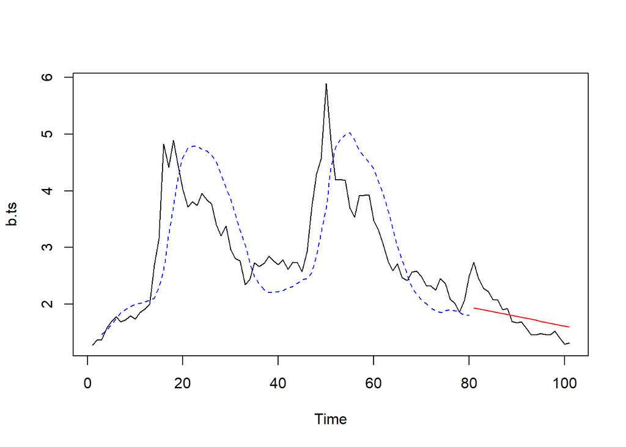

```r
plot(b.ts)
lines(des.1$fitted[,1], lty=2, col="blue")
lines(ramalandes1$mean, col="red")
```

```r
#Lamda dan gamma optimum
des.opt<- HoltWinters(trai.ts, gamma = FALSE)
des.opt
```

```
## Holt-Winters exponential smoothing with trend and without seasonal component.
##
## Call:
## HoltWinters(x = trai.ts, gamma = FALSE)
##
## Smoothing parameters:
##  alpha: 1
##  beta : 0.02442479
##  gamma: FALSE
##
## Coefficients:
##          [,1]
## a 2.499600000
## b 0.008345125
```

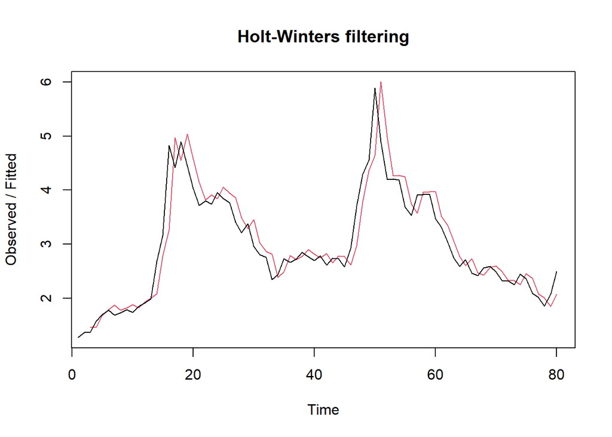

```r
plot(des.opt)
```

```r
#ramalan
ramalandesopt<- forecast(des.opt, h=21)
ramalandesopt
```

```
##     Point Forecast       Lo 80    Hi 80      Lo 95    Hi 95
##  81       2.507945  2.02113068 2.994760  1.7634267 3.252464
##  82       2.516290  1.81937221 3.213208  1.4504461 3.582134
##  83       2.524635  1.66068969 3.388581  1.2033445 3.845926
##  84       2.532981  1.52333046 3.542631  0.9888540 4.077107
##  85       2.541326  1.39898124 3.683670  0.7942607 4.288391
##  86       2.549671  1.28343326 3.815908  0.6131276 4.486214
##  87       2.558016  1.17421818 3.941814  0.4416799 4.674352
##  88       2.566361  1.06974835 4.062974  0.2774895 4.855233
##  89       2.574706  0.96893519 4.180477  0.1188914 5.030521
##  90       2.583051  0.87099652 4.295106 -0.0353105 5.201413
##  91       2.591396  0.77534971 4.407443 -0.1860073 5.368800
##  92       2.599742  0.68154825 4.517935 -0.3338819 5.533365
##  93       2.608087  0.58924197 4.626931 -0.4794698 5.695643
##  94       2.616432  0.49815098 4.734713 -0.6231991 5.856063
##  95       2.624777  0.40804795 4.841506 -0.7654175 6.014971
##  96       2.633122  0.31874571 4.947498 -0.9064111 6.172655
##  97       2.641467  0.23008833 5.052846 -1.0464185 6.329353
##  98       2.649812  0.14194461 5.157680 -1.1856403 6.485265
##  99       2.658157  0.05420315 5.262112 -1.3242470 6.640562
## 100       2.666503 -0.03323136 5.366236 -1.4623841 6.795389
## 101       2.674848 -0.12044107 5.470136 -1.6001775 6.949873
```

##Akurasi Data Latih DES

```r
#Akurasi Data Training
ssedes.train1<-des.1$SSE
msedes.train1<-ssedes.train1/length(trai.ts)
sisaandes1<-ramalandes1$residuals
head(sisaandes1)
```

```
## Time Series:
## Start = 1
## End = 6
## Frequency = 1
## [1]          NA          NA -0.08790000  0.04339600  0.05419696  0.03286985
```

```r
mapedes.train1 <- sum(abs(sisaandes1[3:length(trai.ts)]/trai.ts[3:length(trai.ts)])
                      *100)/length(trai.ts)

akurasides.1 <- matrix(c(ssedes.train1,msedes.train1,mapedes.train1))
row.names(akurasides.1)<- c("SSE", "MSE", "MAPE")
colnames(akurasides.1) <- c("Akurasi lamda=0.2 dan gamma=0.2")
akurasides.1
```

```
##      Akurasi lamda=0.2 dan gamma=0.2
## SSE                       44.8909300
## MSE                        0.5611366
## MAPE                      18.1820463
```

```r
ssedes.train2<-des.2$SSE
msedes.train2<-ssedes.train2/length(trai.ts)
sisaandes2<-ramalandes2$residuals
head(sisaandes2)
```

```
## Time Series:
## Start = 1
## End = 6
## Frequency = 1
## [1]           NA           NA -0.087900000  0.090862000  0.053511640
## [6]  0.001139401
```

```r
mapedes.train2 <- sum(abs(sisaandes2[3:length(trai.ts)]/trai.ts[3:length(trai.ts)])
                      *100)/length(trai.ts)

akurasides.2 <- matrix(c(ssedes.train2,msedes.train2,mapedes.train2))
row.names(akurasides.2)<- c("SSE", "MSE", "MAPE")
colnames(akurasides.2) <- c("Akurasi lamda=0.6 dan gamma=0.3")
akurasides.2
```

```
##      Akurasi lamda=0.6 dan gamma=0.3
## SSE                       15.9961923
## MSE                        0.1999524
## MAPE                       8.7069121
```

Kombinasi λ=0.6, γ=0.3 memberikan akurasi jauh lebih baik dibanding λ=0.2, γ=0.2.Hal ini terlihat dari penurunan drastis SSE, MSE, dan terutama MAPE (turun dari 18% → 8%). Artinya, model DES dengan parameter yang lebih “responsif” (nilai λ dan γ lebih besar) lebih sesuai untuk data latih.

##Akurasi Data Uji DES

```r
#Akurasi Data Testing
selisihdes1<-ramalandes1$mean-test_des$Coffee.Arabica.....kg.
selisihdes1
```

```
## Time Series:
## Start = 81
## End = 101
## Frequency = 1
##  [1] -0.81023958 -0.53259213 -0.38014467 -0.33699722 -0.21874977 -0.22520232
##  [7] -0.07195487 -0.10860742  0.10464004  0.11308749  0.07703494  0.17328239
## [13]  0.27522984  0.26257729  0.21922475  0.21777220  0.20931965  0.12456710
## [19]  0.22511455  0.32266200  0.28400946
```

```r
SSEtestingdes1<-sum(selisihdes1^2)
MSEtestingdes1<-SSEtestingdes1/length(test_des$Coffee.Arabica.....kg.)
MAPEtestingdes1<-sum(abs(selisihdes1/test_des$Coffee.Arabica.....kg.)*100)/length(test_des$Coffee.Arabica.....kg.)

selisihdes2<-ramalandes2$mean-test_des$Coffee.Arabica.....kg.
selisihdes2
```

```
## Time Series:
## Start = 81
## End = 101
## Frequency = 1
##  [1] -0.42347284 -0.07620301  0.14586682  0.25863665  0.44650649  0.50967632
##  [7]  0.73254615  0.76551598  1.04838581  1.12645565  1.16002548  1.32589531
## [13]  1.49746514  1.55443497  1.58070480  1.64887464  1.71004447  1.69491430
## [19]  1.86508413  2.03225396  2.06322380
```

```r
SSEtestingdes2<-sum(selisihdes2^2)
MSEtestingdes2<-SSEtestingdes2/length(test_des$Coffee.Arabica.....kg.)
MAPEtestingdes2<-sum(abs(selisihdes2/test_des$Coffee.Arabica.....kg.)*100)/length(test_des$Coffee.Arabica.....kg.)

selisihdesopt<-ramalandesopt$mean-test_des$Coffee.Arabica.....kg.
selisihdesopt
```

```
## Time Series:
## Start = 81
## End = 101
## Frequency = 1
##  [1] -0.23595487  0.06669025  0.24413538  0.31228050  0.45552563  0.47407075
##  [7]  0.65231588  0.64066100  0.87890613  0.91235125  0.90129638  1.02254150
## [13]  1.14948663  1.16183175  1.14347688  1.16702200  1.18356713  1.12381225
## [19]  1.24935738  1.37190250  1.35824763
```

```r
SSEtestingdesopt<-sum(selisihdesopt^2)
MSEtestingdesopt<-SSEtestingdesopt/length(test_des$Coffee.Arabica.....kg.)
MAPEtestingdesopt<-sum(abs(selisihdesopt/test_des$Coffee.Arabica.....kg.)*100)/length(test_des$Coffee.Arabica.....kg.)

akurasitestingdes <-
  matrix(c(SSEtestingdes1,MSEtestingdes1,MAPEtestingdes1,SSEtestingdes2,MSEtestingdes2,
           MAPEtestingdes2,SSEtestingdesopt,MSEtestingdesopt,MAPEtestingdesopt),
         nrow=3,ncol=3)
row.names(akurasitestingdes)<- c("SSE", "MSE", "MAPE")
colnames(akurasitestingdes) <- c("des ske1","des ske2","des opt")
akurasitestingdes
```

```
##         des ske1  des ske2    des opt
## SSE   1.90842265 34.865315 18.2405241
## MSE   0.09087727  1.660253  0.8685964
## MAPE 13.99628152 73.611278 54.3326107
```

Model terbaik di data uji adalah DES ske1 karena SSE & MSE paling rendah dan MAPE hanya ~14% (masih dalam kategori baik). DES ske2 dan des opt tidak cocok karena hasil prediksi sangat meleset (MAPE > 50%). Jadi, untuk generalisasi ke data uji, ske1 adalah konfigurasi paling stabil.